# Material Complementar — Métodos Locais e Kernels

EST335 — Métodos Estatísticos para Machine Learning

Autor

Prof. Tiago Martins Pereira

## Objetivo

Este material apresenta um roteiro prático para estudar **métodos locais, suavização e kernels** em R. Os exemplos usam dados simulados diferentes dos dados da Atividade 2 e não fornecem sua solução.

A ideia central é perceber que métodos não paramétricos substituem uma forma funcional global rígida por mecanismos que controlam a complexidade localmente.

## 1. Dados para os exemplos

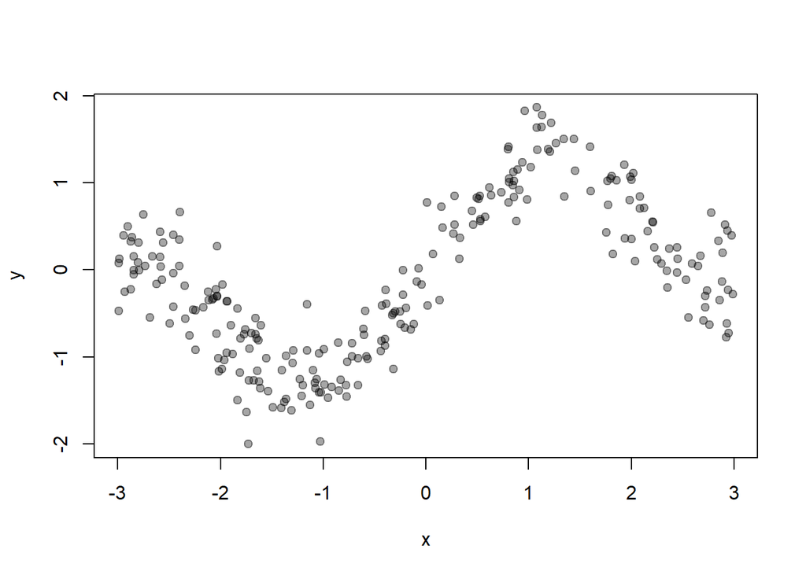

```r
set.seed(335)

n <- 250
x <- runif(n, -3, 3)
y <- sin(1.5*x) + 0.25*x + rnorm(n, sd = 0.35)

dados <- data.frame(x, y)

plot(
  dados$x, dados$y,
  pch = 19, col = rgb(0,0,0,0.35),
  xlab = "x", ylab = "y"
)
```

## 2. KNN como regressão local constante

Para um ponto $x_0$, o KNN usa os $k$ vizinhos mais próximos:

$$\widehat g(x_0)
=
\frac{1}{k}\sum_{i\in N_k(x_0)}y_i.$$

Essa média também resolve

$$\min_{\beta_0}
\sum_{i\in N_k(x_0)}
(y_i-\beta_0)^2.$$

Assim, KNN pode ser interpretado como um **ajuste local de grau zero**.

### Implementação simples

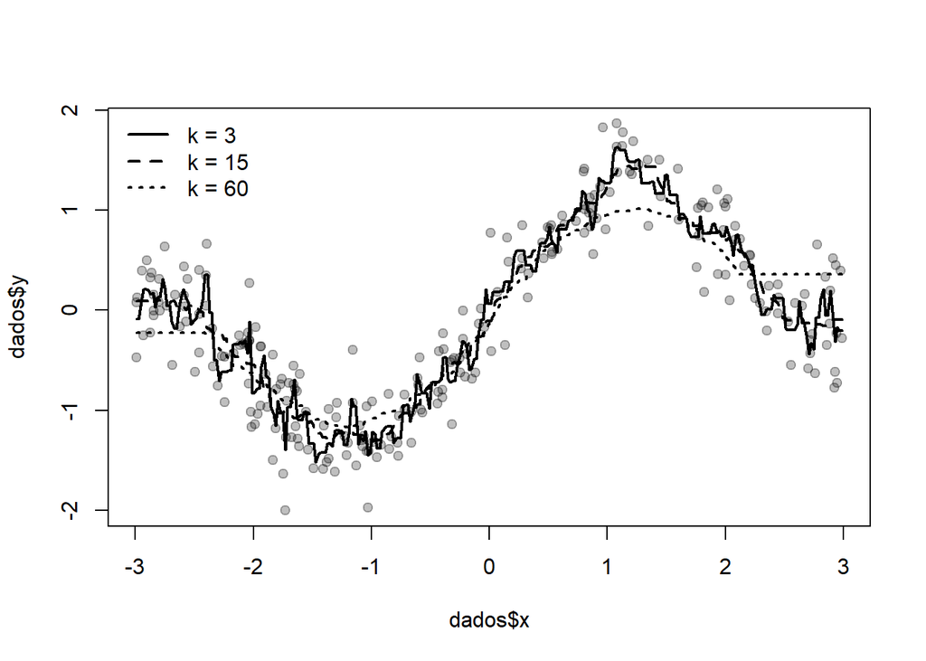

```r
pred_knn <- function(x_train, y_train, x_new, k) {
  sapply(x_new, function(x0) {
    ind <- order(abs(x_train - x0))[1:k]
    mean(y_train[ind])
  })
}

grid <- seq(min(x), max(x), length.out = 300)

p3  <- pred_knn(x, y, grid, k = 3)
p15 <- pred_knn(x, y, grid, k = 15)
p60 <- pred_knn(x, y, grid, k = 60)

plot(dados$x, dados$y, pch = 19, col = rgb(0,0,0,0.25))
lines(grid, p3,  lwd = 2)
lines(grid, p15, lwd = 2, lty = 2)
lines(grid, p60, lwd = 2, lty = 3)
legend(
  "topleft",
  legend = c("k = 3", "k = 15", "k = 60"),
  lty = 1:3, lwd = 2, bty = "n"
)
```

Observe que $k$ funciona como parâmetro de suavização:

$$k\downarrow \Rightarrow \text{modelo mais local e flexível},$$

$$k\uparrow \Rightarrow \text{modelo mais suave}.$$

## 3. Escolha de hiperparâmetros por validação cruzada

O conjunto de teste deve representar dados ainda não utilizados. Portanto, $k$ não deve ser escolhido minimizando o erro de teste.

Um procedimento adequado é:

1. separar treino e teste;
2. executar validação cruzada apenas no treino;
3. selecionar $k$;
4. ajustar o procedimento escolhido;
5. avaliar uma única vez no teste.

O mesmo princípio será usado para $h$, $\lambda$ e outros hiperparâmetros.

## 4. Nadaraya–Watson

O estimador é

$$\widehat g_h(x_0)
=
\frac{
\sum_i K\left(\frac{x_i-x_0}{h}\right)y_i
}{
\sum_i K\left(\frac{x_i-x_0}{h}\right)
}.$$

Com kernel Gaussiano:

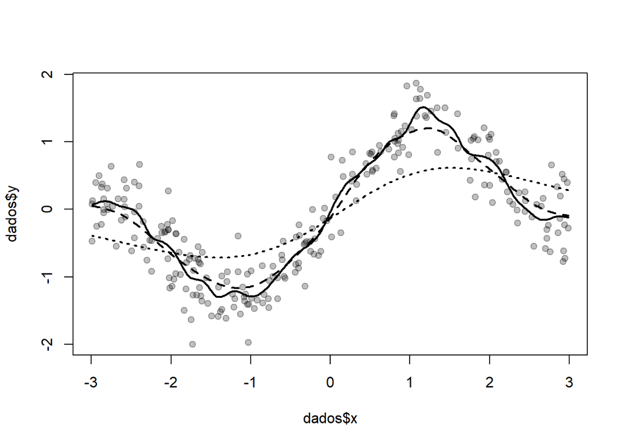

```r
K_gauss <- function(u) {
  dnorm(u)
}

nw <- function(x_train, y_train, x_new, h) {
  sapply(x_new, function(x0) {
    w <- K_gauss((x_train - x0)/h)
    sum(w*y_train) / sum(w)
  })
}

h1 <- nw(x, y, grid, h = 0.10)
h2 <- nw(x, y, grid, h = 0.35)
h3 <- nw(x, y, grid, h = 1.00)

plot(dados$x, dados$y, pch = 19, col = rgb(0,0,0,0.25))
lines(grid, h1, lwd = 2)
lines(grid, h2, lwd = 2, lty = 2)
lines(grid, h3, lwd = 2, lty = 3)
```

$$h\downarrow
\Rightarrow
\text{maior localidade},$$

enquanto

$$h\uparrow
\Rightarrow
\text{maior suavização}.$$

## 5. KNN versus kernel

No KNN, uma representação simplificada dos pesos é

$$w_i(x_0)
=
\begin{cases}
1/k, & x_i\in N_k(x_0),\\
0, & \text{caso contrário}.
\end{cases}$$

No Nadaraya–Watson,

$$w_i(x_0)
=
\frac{
K\left((x_i-x_0)/h\right)
}{
\sum_j K\left((x_j-x_0)/h\right)
}.$$

Assim, o kernel permite que a importância das observações varie continuamente com a distância.

## 6. Regressão polinomial local

Em vez de assumir que a função é constante perto de $x_0$, podemos aproximá-la localmente por

$$y_i
\approx
\beta_0(x_0)
+
\beta_1(x_0)(x_i-x_0).$$

O ajuste é obtido por mínimos quadrados ponderados:

$$\min_{\beta_0,\beta_1}
\sum_i
K\left(\frac{x_i-x_0}{h}\right)
\left[
y_i-\beta_0-\beta_1(x_i-x_0)
\right]^2.$$

Em R, `loess()` permite explorar essa ideia:

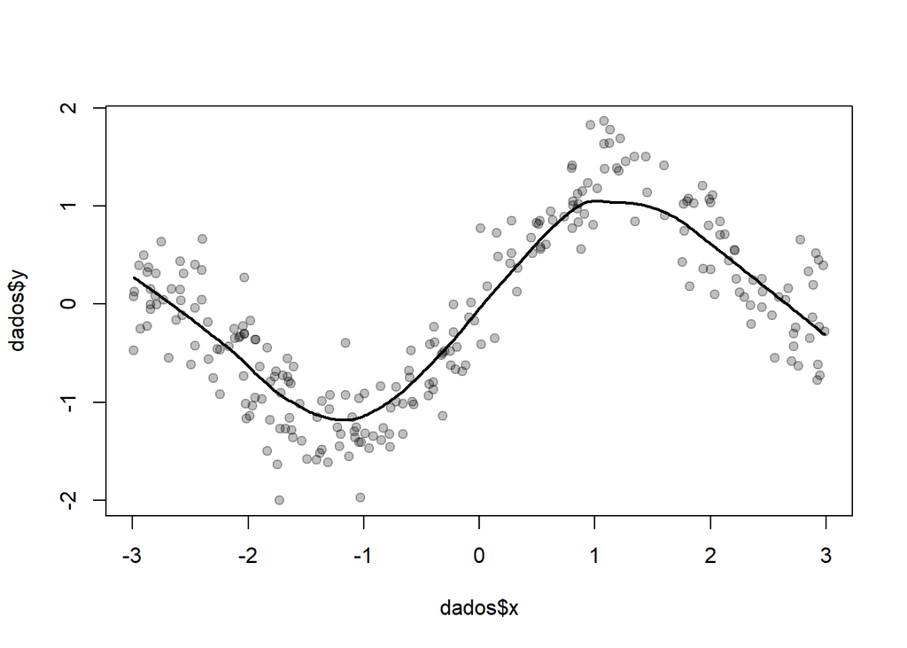

```r
ajuste <- loess(
  y ~ x,
  data = dados,
  degree = 1,
  span = 0.35
)

pred <- predict(
  ajuste,
  newdata = data.frame(x = grid)
)

plot(dados$x, dados$y, pch = 19, col = rgb(0,0,0,0.25))
lines(grid, pred, lwd = 2)
```

Uma vantagem importante do ajuste linear local é seu comportamento próximo às fronteiras.

## 7. Variáveis irrelevantes e distância

Considere que a resposta dependa principalmente de $x_1$, mas adicionemos variáveis independentes $z_1,z_2,\ldots$.

Em métodos baseados em distância, a noção de “vizinho” passa a depender de todas as coordenadas utilizadas.

Com o aumento da dimensão, os pontos tendem a ficar mais esparsos no espaço:

$$d\uparrow
\quad\Rightarrow\quad
\text{vizinhanças locais tornam-se menos informativas}.$$

Esse fenômeno está relacionado à **maldição da dimensionalidade**.

Por isso, padronização e seleção de covariáveis são especialmente relevantes para KNN.

## 8. Kernel Ridge

Na regressão Ridge tradicional:

$$\widehat\beta
=
\arg\min_\beta
\left\{
\sum_i(y_i-x_i^\top\beta)^2
+
\lambda\|\beta\|_2^2
\right\}.$$

Em um espaço de Hilbert com kernel, podemos considerar

$$\widehat f
=
\arg\min_{f\in\mathcal H}
\left\{
\frac1n\sum_i(y_i-f(x_i))^2
+
\lambda\|f\|_{\mathcal H}^2
\right\}.$$

O primeiro termo controla o ajuste aos dados. O segundo controla a complexidade da função.

Pelo Teorema do Representante, a solução pode ser escrita como

$$\widehat f(x)
=
\sum_{i=1}^{n}\alpha_i K(x_i,x).$$

Assim, não é necessário trabalhar explicitamente com todas as coordenadas do espaço de características induzido pelo kernel.

## 9. Kernel Gaussiano

Um kernel muito utilizado é

$$K(x,x')
=
\exp\left(
-\gamma\|x-x'\|^2
\right).$$

O parâmetro $\gamma$ controla a escala de similaridade, enquanto $\lambda$ controla a regularização.

Portanto, existem dois mecanismos distintos:

$$\gamma
\rightarrow
\text{geometria/localidade do kernel},$$

$$\lambda
\rightarrow
\text{penalização da complexidade}.$$

## 10. O que observar na prática

Ao comparar os métodos, não se limite a perguntar qual produz o menor RMSE.

Pergunte também:

- como a curva muda quando o parâmetro de suavização muda?
- o que acontece nas fronteiras?
- como o método reage a regiões com poucos dados?
- o que ocorre quando covariáveis irrelevantes entram na distância?
- como o desempenho de validação se relaciona ao desempenho de teste?
- quais parâmetros controlam a complexidade em cada método?

A comparação dessas respostas é mais importante para a compreensão estatística dos métodos do que a simples ordenação das métricas.